# Yerdle Homebody Data Analysis

Yiwen Zheng, 10/20/2019

```python
%matplotlib inline
import pandas as pd
import numpy as np
import requests
import matplotlib.pyplot as plt
from matplotlib.ticker import (MultipleLocator, FormatStrFormatter,
                               AutoMinorLocator)
import matplotlib.ticker as ticker
import seaborn as sns
import datetime
from matplotlib.dates import DateFormatter
import matplotlib.dates as mdates
```

```python
plt.rcParams['figure.figsize'] = 15,6
```

```python
hb_sales=pd.read_csv('partnerships-data.csv')
```

```python
hb_sales.isna().sum()
```

```
Department                       0
Category                         0
Condition Group                  0
Sales Week                       0
Net Item Revenue (Fulfilled)     0
Net Items (Fulfilled)            0
Gross Orders (Fulfilled)         0
Net Sell Through Items (Week)    7
MSRP of Sold Items               0
Avg. Item Age When Sold          0
Avg. Item Age EOW                0
EOW Inventory For Sale $         0
EOW Inventory For Sale Items     0
MSRP of EOW Inventory            0
dtype: int64
```

we have 7 missing data for Net Sell Through Items (Week)

```python
hb_sales.nunique()
```

```
Department                          7
Category                           23
Condition Group                     3
Sales Week                         15
Net Item Revenue (Fulfilled)      942
Net Items (Fulfilled)             108
Gross Orders (Fulfilled)           97
Net Sell Through Items (Week)     264
MSRP of Sold Items               1077
Avg. Item Age When Sold          1281
Avg. Item Age EOW                1519
EOW Inventory For Sale $         1617
EOW Inventory For Sale Items      577
MSRP of EOW Inventory            1665
dtype: int64
```

in total, this dataset contains 15 sales weeks information, including 23 categories for 7 departments

data cleaning, convert currency str to float

```python
hb_sales['Net Item Revenue (Fulfilled)']=hb_sales['Net Item Revenue (Fulfilled)'].\
str.replace(',', '').str.replace('$', '').str.strip(')').str.replace('(', '-').astype(float)
```

```python
hb_sales['Net Items (Fulfilled)']=hb_sales['Net Items (Fulfilled)'].\
str.replace(',', '').str.replace('$', '').str.strip(')').str.replace('(', '-').astype(float)
```

```python
hb_sales['MSRP of Sold Items']=hb_sales['MSRP of Sold Items'].\
str.replace(',', '').str.replace('$', '').str.strip(')').str.replace('(', '-').astype(float)
```

```python
hb_sales['EOW Inventory For Sale $']=hb_sales['EOW Inventory For Sale $'].\
str.replace(',', '').str.replace('$', '').str.strip(')').str.replace('(', '-').astype(float)
```

```python
hb_sales['MSRP of EOW Inventory']=hb_sales['MSRP of EOW Inventory'].\
str.replace(',', '').str.replace('$', '').str.strip(')').str.replace('(', '-').astype(float)
```

```python
hb_sales['Net Sell Through Items (Week)']=hb_sales['Net Sell Through Items (Week)'].\
str.replace(',', '').str.replace('$', '').str.strip(')%').str.replace('(', '-').astype(float)
```

```python
hb_sales['EOW Inventory For Sale Items']=hb_sales['EOW Inventory For Sale Items'].\
str.replace(',', '').str.replace('$', '').str.strip(')%').str.replace('(', '-').astype(float)
```

```python
format_str = '%m/%d/%y'
hb_sales['Sales Week']=hb_sales['Sales Week'].apply(lambda x: datetime.datetime.strptime(x,format_str).date())
```

```python
columns_list=hb_sales.columns.to_list()[4:]
```

**overal trend on all metrics**

```python
col2agg = {
 'Net Item Revenue (Fulfilled)':'sum',
 'Net Items (Fulfilled)':'sum',
 'Gross Orders (Fulfilled)':'sum',
 'Net Sell Through Items (Week)':'mean',
 'MSRP of Sold Items':'sum',
 'Avg. Item Age When Sold':'mean',
 'Avg. Item Age EOW':'mean',
 'EOW Inventory For Sale $':'sum',
 'EOW Inventory For Sale Items':'sum',
 'MSRP of EOW Inventory':'sum'
}
```

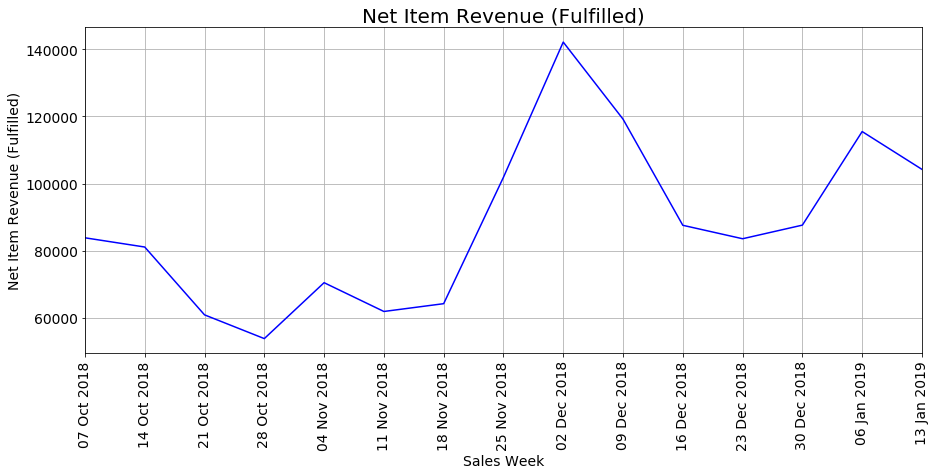

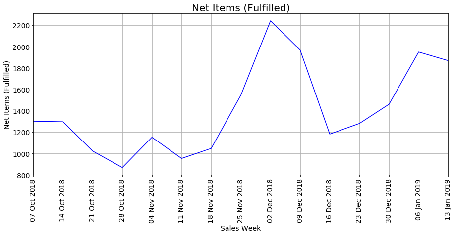

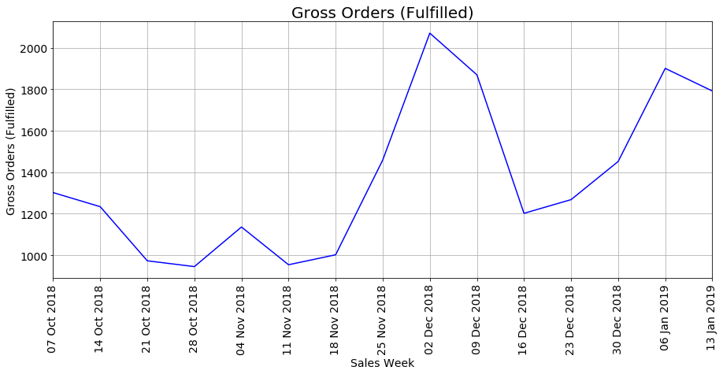

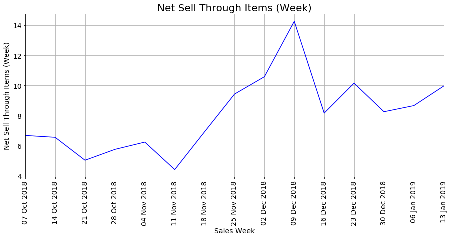

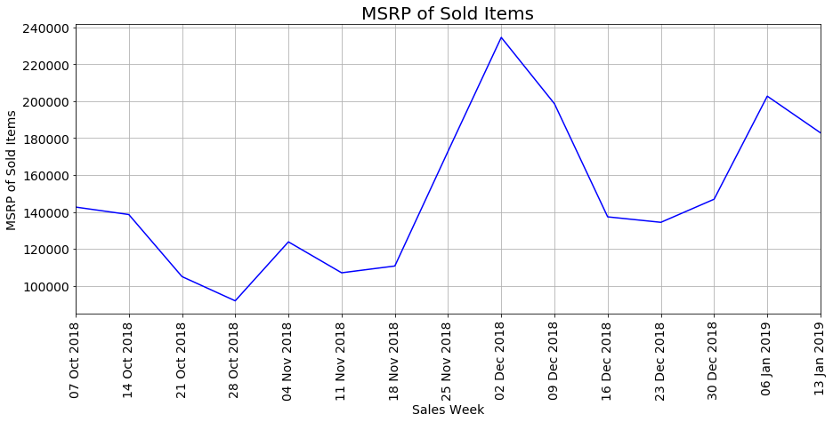

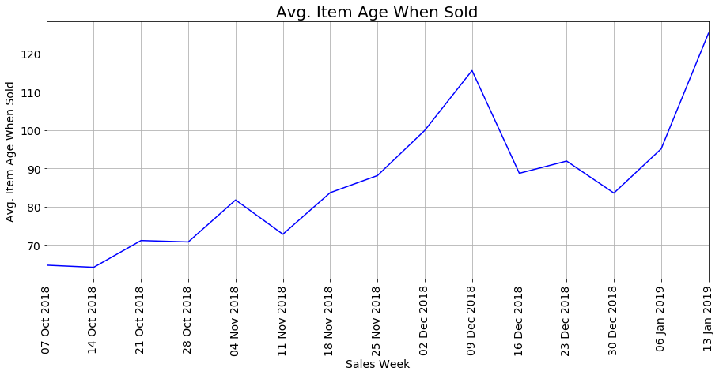

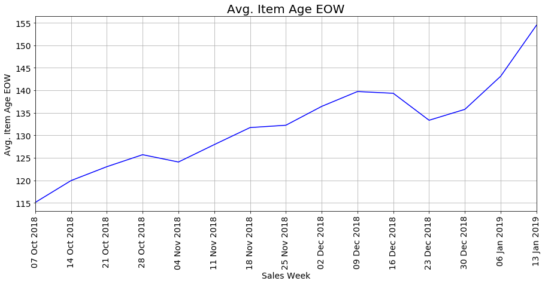

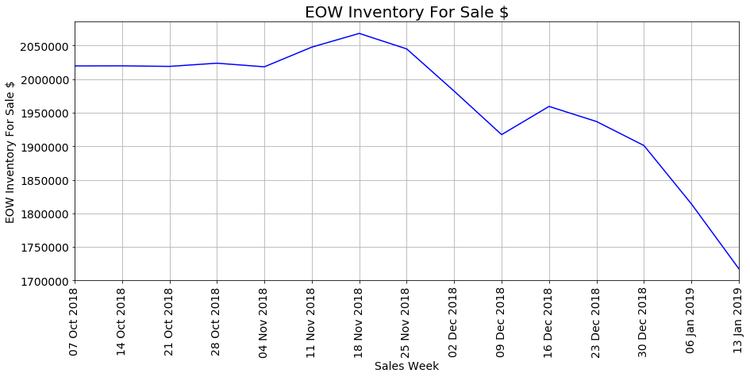

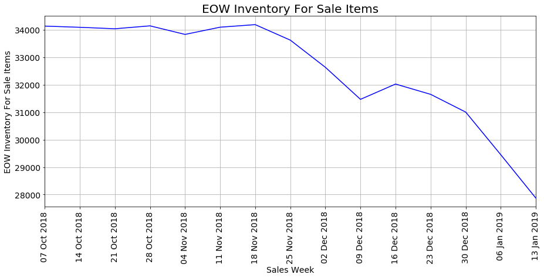

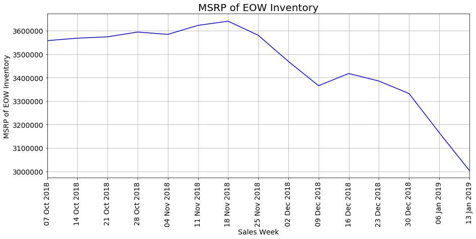

```python
for col, agg_method in col2agg.items():
    ax=hb_sales.groupby('Sales Week')[col].agg(agg_method).plot(label=col, color='Blue')
    plt.title(col,fontsize=20)
    plt.ylabel(col,fontsize=14)
    plt.xlabel('Sales Week',fontsize=14)
    plt.grid(True)
    ax.xaxis.set_major_locator(mdates.WeekdayLocator(byweekday=mdates.SU))
    ax.xaxis.set_major_formatter(mdates.DateFormatter('%d %b %Y'))
    plt.xticks(fontsize=14,rotation=90)
    plt.yticks(fontsize=14)
    plt.show()
```

Conclusion: we have highest revenue in Dec. Then it is gradually trending down. This might be caused by seasonality. We can further breakdown the reveune in departments to understand each department's performance. Moreover, the time for items to be sold has been increased drastically.

**Revenue by department**

```python
weekly_revenue_by_dept=\
hb_sales.groupby(['Sales Week','Department'])['Net Item Revenue (Fulfilled)'].sum().reset_index()
```

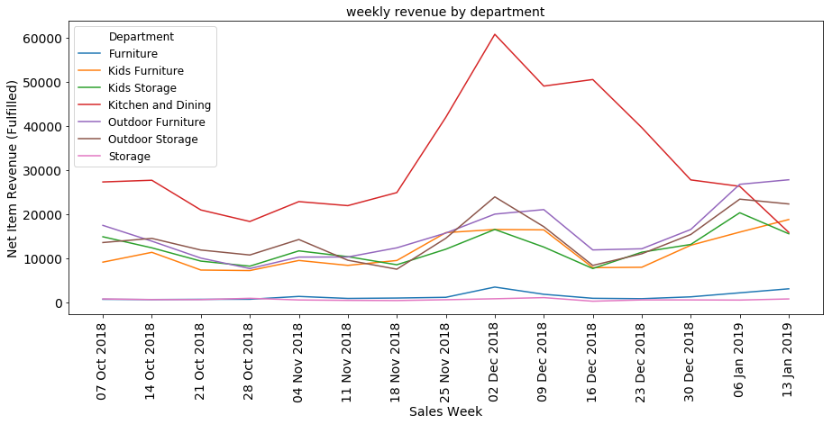

```python
ax=sns.lineplot(x='Sales Week',y='Net Item Revenue (Fulfilled)', hue='Department',data=weekly_revenue_by_dept)
plt.title('weekly revenue by department',fontsize=14)
plt.xticks(fontsize=14,rotation=90)
plt.yticks(fontsize=14)
ax.xaxis.set_major_locator(mdates.WeekdayLocator(byweekday=mdates.SU))
ax.xaxis.set_major_formatter(mdates.DateFormatter('%d %b %Y'))
plt.xlabel('Sales Week',fontsize=14)
plt.ylabel('Net Item Revenue (Fulfilled)',fontsize=14)
plt.legend(fontsize=12, loc=0)
plt.show()
```

```python
weekly_revenue_by_week = weekly_revenue_by_dept.pivot(index='Sales Week', columns='Department')
```

```python
weekly_revenue_by_week.corr()
```

|  | Department | Net Item Revenue (Fulfilled) Furniture | Net Item Revenue (Fulfilled) Kids Furniture | Net Item Revenue (Fulfilled) Kids Storage | Net Item Revenue (Fulfilled) Kitchen and Dining | Net Item Revenue (Fulfilled) Outdoor Furniture | Net Item Revenue (Fulfilled) Outdoor Storage | Net Item Revenue (Fulfilled) Storage |
| --- | --- | --- | --- | --- | --- | --- | --- | --- |
| Net Item Revenue (Fulfilled) | Furniture | 1.000000 | 0.817404 | 0.673384 | 0.318008 | 0.767303 | 0.863321 | 0.337214 |
|  | Kids Furniture | 0.817404 | 1.000000 | 0.721721 | 0.277153 | 0.879691 | 0.854687 | 0.396247 |
|  | Kids Storage | 0.673384 | 0.721721 | 1.000000 | 0.088489 | 0.851872 | 0.898546 | 0.265561 |
|  | Kitchen and Dining | 0.318008 | 0.277153 | 0.088489 | 1.000000 | 0.136218 | 0.186834 | 0.084898 |
|  | Outdoor Furniture | 0.767303 | 0.879691 | 0.851872 | 0.136218 | 1.000000 | 0.853979 | 0.310876 |
|  | Outdoor Storage | 0.863321 | 0.854687 | 0.898546 | 0.186834 | 0.853979 | 1.000000 | 0.446020 |
|  | Storage | 0.337214 | 0.396247 | 0.265561 | 0.084898 | 0.310876 | 0.446020 | 1.000000 |

Kitchen and Dinning was the main driver in revenue. The revenue on Kids Furniture, Kids Storage, Outdoor Furniture and Outdoor Storage are highly correlated. It might be beneficial to plan the inventory of these department at similar level

**Return spike**

```python
weekly_rc_by_dept=hb_sales.loc[hb_sales['Net Item Revenue (Fulfilled)']<=0,:].\
groupby(['Sales Week','Department'])['Net Item Revenue (Fulfilled)'].sum().reset_index()
```

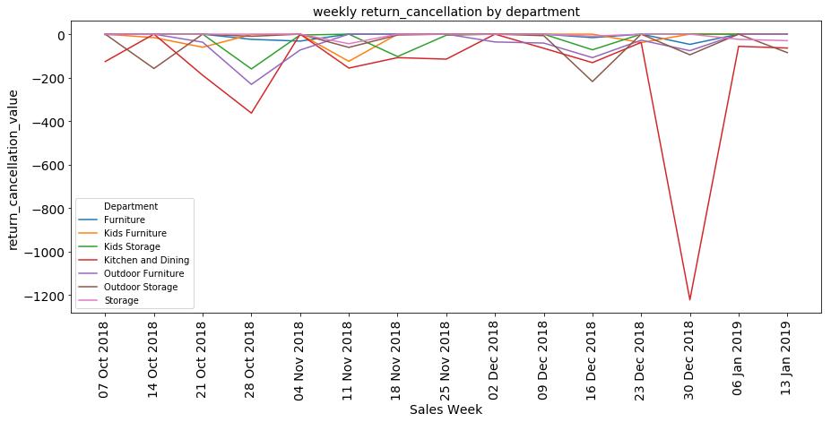

```python
ax=sns.lineplot(x='Sales Week',y='Net Item Revenue (Fulfilled)', hue='Department',data=weekly_rc_by_dept)
plt.title('weekly return_cancellation by department',fontsize=14)
plt.xticks(fontsize=14,rotation=90)
plt.yticks(fontsize=14)
plt.xlabel('Sales Week',fontsize=14)
plt.ylabel('return_cancellation_value',fontsize=14)
ax.xaxis.set_major_locator(mdates.WeekdayLocator(byweekday=mdates.SU))
ax.xaxis.set_major_formatter(mdates.DateFormatter('%d %b %Y'))
plt.legend(fontsize=10,loc=0)
plt.show()
```

the peak sales at the week of 2018-12-02 is followed by a return spike at the week of 2018-12-30, returned products are mainly from kitchen and dinning department, which accounts for about 1% of the revenue at the week of 2018-12-02

**further breakdown analysis on Kitchen and Dinning Department**

```python
Kitchen_Dinning_Category_Revenue=hb_sales.\
loc[hb_sales.Department=='Kitchen and Dining',\
    ['Category','Condition Group','Net Item Revenue (Fulfilled)','Sales Week']]
```

```python
KDC_WR=Kitchen_Dinning_Category_Revenue.\
groupby(['Sales Week','Category','Condition Group'])['Net Item Revenue (Fulfilled)'].sum().reset_index()
```

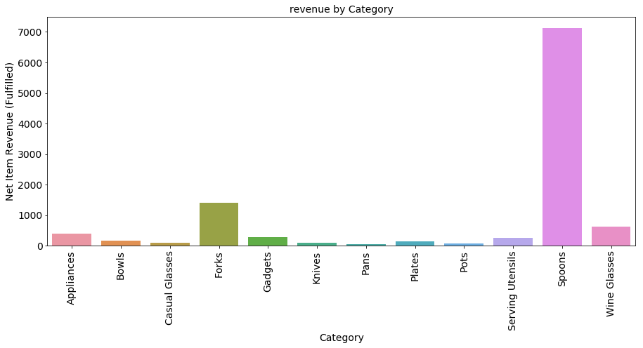

```python
sns.barplot(x='Category',y='Net Item Revenue (Fulfilled)',data=KDC_WR,ci=0)
plt.title('revenue by Category',fontsize=14)
plt.xticks(fontsize=14,rotation=90)
plt.yticks(fontsize=14)
plt.xlabel('Category',fontsize=14)
plt.ylabel('Net Item Revenue (Fulfilled)',fontsize=14)
plt.show()
```

```python
weekly_rc_by_cy=hb_sales.loc[hb_sales['Net Item Revenue (Fulfilled)']<=0,:].\
groupby(['Sales Week','Department','Category'])['Net Item Revenue (Fulfilled)'].sum().reset_index()
```

```python
KDC_rn=weekly_rc_by_cy.\
groupby(['Sales Week','Category'])['Net Item Revenue (Fulfilled)'].sum().reset_index()
```

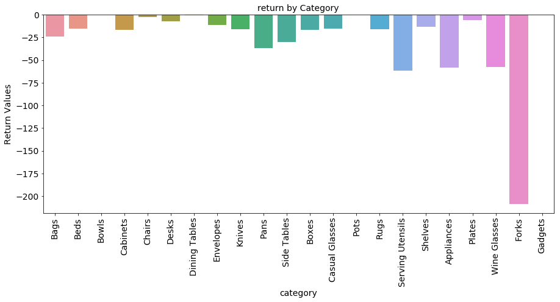

```python
sns.barplot(x='Category',y='Net Item Revenue (Fulfilled)',data=KDC_rn,ci=0)
plt.title('return by Category',fontsize=14)
plt.xticks(fontsize=14,rotation=90)
plt.yticks(fontsize=14)
plt.xlabel('category',fontsize=14)
plt.ylabel('Return Values',fontsize=14)
plt.show()
```

the revenue in kitchen and dinining is mainly driven by Spoons, which is followed by forks.

**Analysis on sell through rate**

```python
sell_through=hb_sales[['Sales Week','Department','Category','Condition Group','Net Sell Through Items (Week)']]
```

```python
st_by_dempt_mean=sell_through.groupby(['Sales Week','Department'])\
['Net Sell Through Items (Week)'].mean().reset_index()
```

```python
st_by_dempt_mean.head(5)
```

|  | Sales Week | Department | Net Sell Through Items (Week) |
| --- | --- | --- | --- |
| 0 | 2018-10-07 | Furniture | 0.512500 |
| 1 | 2018-10-07 | Kids Furniture | 2.200000 |
| 2 | 2018-10-07 | Kids Storage | 7.452381 |
| 3 | 2018-10-07 | Kitchen and Dining | 14.705882 |
| 4 | 2018-10-07 | Outdoor Furniture | 3.133333 |

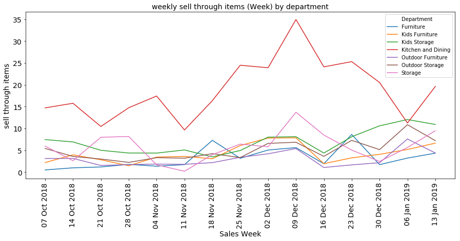

```python
ax=sns.lineplot(x='Sales Week',y='Net Sell Through Items (Week)', hue='Department',data=st_by_dempt_mean)
plt.title('weekly sell through items (Week) by department',fontsize=14)
plt.xticks(fontsize=14,rotation=90)
plt.yticks(fontsize=14)
plt.xlabel('Sales Week',fontsize=14)
plt.ylabel('sell through items',fontsize=14)
ax.xaxis.set_major_locator(mdates.WeekdayLocator(byweekday=mdates.SU))
ax.xaxis.set_major_formatter(mdates.DateFormatter('%d %b %Y'))
plt.legend(fontsize=10,loc=0)
plt.show()
```

```python
st_by_week =st_by_dempt_mean.pivot(index='Sales Week', columns='Department')
```

```python
st_by_week.corr()
```

|  | Department | Net Sell Through Items (Week) Furniture | Net Sell Through Items (Week) Kids Furniture | Net Sell Through Items (Week) Kids Storage | Net Sell Through Items (Week) Kitchen and Dining | Net Sell Through Items (Week) Outdoor Furniture | Net Sell Through Items (Week) Outdoor Storage | Net Sell Through Items (Week) Storage |
| --- | --- | --- | --- | --- | --- | --- | --- | --- |
| Net Sell Through Items (Week) | Furniture | 1.000000 | 0.377359 | 0.143635 | 0.517680 | 0.176970 | 0.457792 | 0.236487 |
|  | Kids Furniture | 0.377359 | 1.000000 | 0.504579 | 0.537897 | 0.694605 | 0.518888 | 0.337144 |
|  | Kids Storage | 0.143635 | 0.504579 | 1.000000 | 0.122353 | 0.698694 | 0.845096 | 0.144540 |
|  | Kitchen and Dining | 0.517680 | 0.537897 | 0.122353 | 1.000000 | 0.142698 | 0.201215 | 0.548065 |
|  | Outdoor Furniture | 0.176970 | 0.694605 | 0.698694 | 0.142698 | 1.000000 | 0.802509 | 0.332325 |
|  | Outdoor Storage | 0.457792 | 0.518888 | 0.845096 | 0.201215 | 0.802509 | 1.000000 | 0.238701 |
|  | Storage | 0.236487 | 0.337144 | 0.144540 | 0.548065 | 0.332325 | 0.238701 | 1.000000 |

**Analysis on the age_sold spike**

```python
age_sold=hb_sales[['Sales Week','Department','Category','Condition Group','Avg. Item Age When Sold']]
```

```python
ag_by_dempt_mean=age_sold.groupby(['Sales Week','Department'])\
['Avg. Item Age When Sold'].mean().reset_index()
```

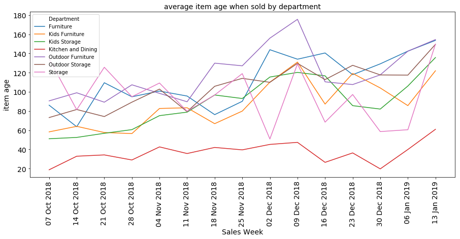

```python
ax=sns.lineplot(x='Sales Week',y='Avg. Item Age When Sold', hue='Department',data=ag_by_dempt_mean)
plt.title('average item age when sold by department',fontsize=14)
plt.xticks(fontsize=14,rotation=90)
plt.yticks(fontsize=14)
plt.xlabel('Sales Week',fontsize=14)
plt.ylabel('item age',fontsize=14)
plt.legend(fontsize=10,loc=0)
ax.xaxis.set_major_locator(mdates.WeekdayLocator(byweekday=mdates.SU))
ax.xaxis.set_major_formatter(mdates.DateFormatter('%d %b %Y'))
plt.show()
```

Overall, the times on selling products are increasing for all departments.

**Understanding of Discount Rate ( relation with items sold and revenue )**

```python
EOW_discount=hb_sales[['Sales Week','Department','Category','Condition Group',\
                       'MSRP of EOW Inventory','EOW Inventory For Sale $','Net Items (Fulfilled)',\
                      'Net Item Revenue (Fulfilled)']]
```

```python
EOW_discount=EOW_discount.\
groupby(['Sales Week','Department']).\
agg({'EOW Inventory For Sale $':'sum',\
     'MSRP of EOW Inventory':'sum',\
     'Net Items (Fulfilled)' :'mean',\
    'Net Item Revenue (Fulfilled)':'sum'}).reset_index()
```

```python
EOW_discount['rough_discount_rate']=1-(EOW_discount['MSRP of EOW Inventory']-\
EOW_discount['EOW Inventory For Sale $'])/EOW_discount['EOW Inventory For Sale $']
```

```python
EOW_discount.drop(columns=['EOW Inventory For Sale $','MSRP of EOW Inventory'],inplace=True)
```

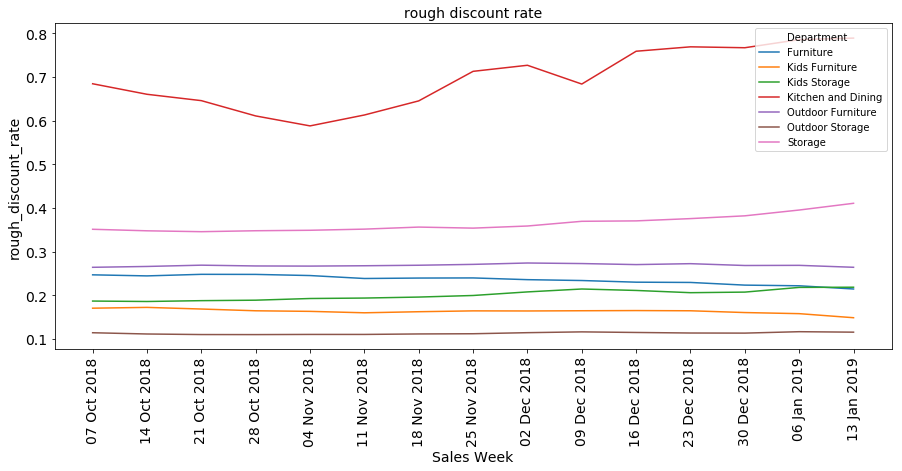

```python
ax=sns.lineplot(x='Sales Week',y='rough_discount_rate', hue='Department',data=EOW_discount)
plt.title('rough discount rate',fontsize=14)
plt.xticks(fontsize=14,rotation=90)
plt.yticks(fontsize=14)
plt.xlabel('Sales Week',fontsize=14)
plt.ylabel('rough_discount_rate',fontsize=14)
ax.xaxis.set_major_locator(mdates.WeekdayLocator(byweekday=mdates.SU))
ax.xaxis.set_major_formatter(mdates.DateFormatter('%d %b %Y'))
plt.legend(fontsize=10,loc=0)
plt.show()
```

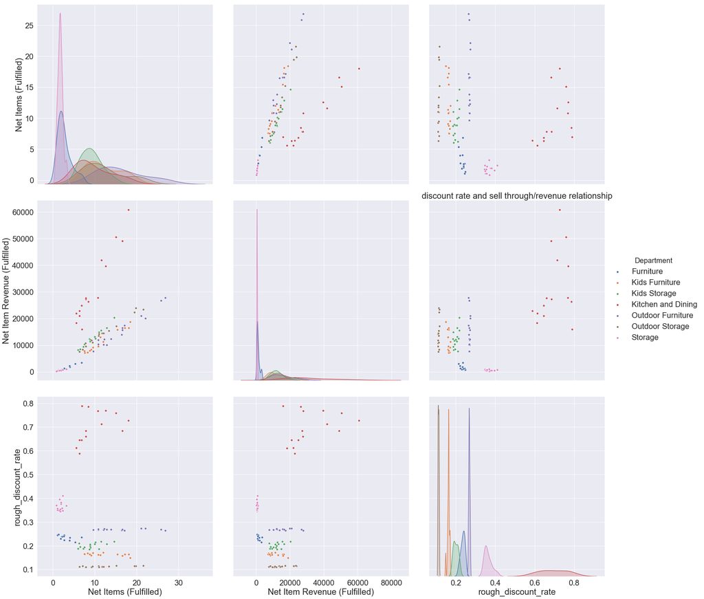

```python
sns.set(font_scale=2)
sns.pairplot(data=EOW_discount,hue='Department', height=8, aspect=1)
plt.title('discount rate and sell through/revenue relationship')
plt.show()
```

```python
EOW_discount.groupby('Department').corr()
```

| Department |  | Net Items (Fulfilled) | Net Item Revenue (Fulfilled) | rough_discount_rate |
| --- | --- | --- | --- | --- |
| Furniture | Net Items (Fulfilled) | 1.000000 | 0.985002 | -0.563721 |
|  | Net Item Revenue (Fulfilled) | 0.985002 | 1.000000 | -0.583000 |
|  | rough_discount_rate | -0.563721 | -0.583000 | 1.000000 |
| Kids Furniture | Net Items (Fulfilled) | 1.000000 | 0.978566 | -0.471766 |
|  | Net Item Revenue (Fulfilled) | 0.978566 | 1.000000 | -0.520732 |
|  | rough_discount_rate | -0.471766 | -0.520732 | 1.000000 |
| Kids Storage | Net Items (Fulfilled) | 1.000000 | 0.990258 | 0.535171 |
|  | Net Item Revenue (Fulfilled) | 0.990258 | 1.000000 | 0.480396 |
|  | rough_discount_rate | 0.535171 | 0.480396 | 1.000000 |
| Kitchen and Dining | Net Items (Fulfilled) | 1.000000 | 0.963438 | 0.487367 |
|  | Net Item Revenue (Fulfilled) | 0.963438 | 1.000000 | 0.342734 |
|  | rough_discount_rate | 0.487367 | 0.342734 | 1.000000 |
| Outdoor Furniture | Net Items (Fulfilled) | 1.000000 | 0.979342 | -0.021681 |
|  | Net Item Revenue (Fulfilled) | 0.979342 | 1.000000 | -0.038397 |
|  | rough_discount_rate | -0.021681 | -0.038397 | 1.000000 |
| Outdoor Storage | Net Items (Fulfilled) | 1.000000 | 0.990451 | 0.682099 |
|  | Net Item Revenue (Fulfilled) | 0.990451 | 1.000000 | 0.607800 |
|  | rough_discount_rate | 0.682099 | 0.607800 | 1.000000 |
| Storage | Net Items (Fulfilled) | 1.000000 | 0.927231 | 0.243691 |
|  | Net Item Revenue (Fulfilled) | 0.927231 | 1.000000 | -0.010473 |
|  | rough_discount_rate | 0.243691 | -0.010473 | 1.000000 |

**Positive Correlation**  
Kids Storage, Kitchen and Dining,Outdoor Storage are positively correlated with discount rate, with higher discount rate, more items can be sold.  
**Negative Correlation**  
Furniture, Kids Furniture are negatively correlated with discount rate, with higher discount rate, less items can be sold, or the vice versa.  
**No Correlation**  
The sold number of items on Outdoor Furniture and Storage is not correlated with discount rate.

**Conclusion and Suggestions:**

1. We have a peak sales at the week of 2018-12-02, which is followed by a return spike at the week of 2018-12-30. Returned products are mainly from kitchen and dinning department, which accounts for about 1% of the revenue at the week of 2018-12-02.
2. Kitchen and Dinning was the main driver in revenue. Particuarly for spoons and forks, the sell through rates are the highest among all departments. Spoons has highest revenues and no orders are returned. From the last 15 weeks, there is no returned orders for spoons. Moreover, the revenue on Kids Furniture, Kids Storage, Outdoor Furniture and Outdoor Storage are highly correlated and at similar magnitude. It might be beneficial to plan the inventory of these department at similar level.
3. Overall, the times on selling products are increasing for all departments, further analysis is needed to understand the reason, it might be caused by some common factors.
4. Kids Storage, Kitchen and Dining,Outdoor Storage are positively correlated with discount rate, with higher discount rate, more items can be sold.Furniture, Kids Furniture are negatively correlated with discount rate, with higher discount rate, less items can be sold, or the vice versa. The sold number of items on Outdoor Furniture and Storage is not correlated with discount rate.